# How to create a Heatmap

2022-05-20

## Downloading Data

For this session we are going to utilise the dataset from the https://encode.project.org/.

## Install Packages and Loading Libraries

First step is to install packages either from CRAN, Bioconductor or from Github and to load the libraries.

```r
library(data.table)
library(dplyr)
library(tidyverse)
library(plyr)
library(scales)
library(tidyquant)
```

## Importing Data

Navigate your directory to your folder where you have saved the data set. Now we will go ahead to import our data set using the fread command.

```r
my_data <- fread(filename)
```

## Data wrangling

In order to have a clean data set we need to add column names and to remove the columns that are not needed for our final heatmap output.

```r
colnames(my_data)[1:4] <- c("chrom","start","stop","type")
my_data <- my_data[,c(1:4)] #Keeping only the columns 1 to 4
my_data$type <- gsub('[[:digit:]]+_','',my_data$type) #removing the numbers and underscores from our type column
glimpse(my_data)
```

```
## Rows: 571,339
## Columns: 4
## $ chrom <chr> "chr1", "chr1", "chr1", "chr1", "chr1", "chr1", "chr1", "chr1", …
## $ start <int> 10000, 10600, 11137, 11737, 11937, 12137, 14537, 20337, 22137, 2…
## $ stop  <int> 10600, 11137, 11737, 11937, 12137, 14537, 20337, 22137, 22937, 2…
## $ type  <chr> "Repetitive/CNV", "Heterochrom/lo", "Insulator", "Weak_Txn", "We…
```

## Split data frame

We can now split our data frame by chromosome and type and apply a function summarizing the length for each type per chromosome using the **ddply** function from the **plyr** library.

```r
my_data2 <- ddply(my_data, .(type, chrom), summarise , no = length(type))
glimpse(my_data2)
```

```
## Rows: 276
## Columns: 3
## $ type  <chr> "Active_Promoter", "Active_Promoter", "Active_Promoter", "Active…
## $ chrom <chr> "chr1", "chr10", "chr11", "chr12", "chr13", "chr14", "chr15", "c…
## $ no    <int> 1497, 596, 759, 788, 323, 498, 492, 668, 901, 243, 1085, 1011, 3…
```

## Pivot_longer & Pivot_wider

**pivot_longer()** makes dataset **longer** by increasing the number of rows and decreasing the number of columns, whereas **pivot_wider()** is often utilized to tidy long data sets and often required for the purpose of the analysis (for examples creating a heatmap)

```r
my_data_final <- my_data2 %>% group_by(type) %>%
  mutate(prop = no/sum(no)) %>%
  ungroup() %>%
  pivot_wider(
    id_cols = type,
    names_from = chrom,
    values_from = prop
  ) %>% arrange(-`chr19`) %>%
  mutate(type = fct_reorder(type, `chr19`)) %>%
  pivot_longer(
    cols = -type,
    names_to = "chrom",
    values_to = "prop"
  )

head(my_data_final)
```

```
## # A tibble: 6 × 3
##   type          chrom    prop
##   <fct>         <chr>   <dbl>
## 1 Weak_Enhancer chr1  0.0299
## 2 Weak_Enhancer chr10 0.0151
## 3 Weak_Enhancer chr11 0.0148
## 4 Weak_Enhancer chr12 0.0158
## 5 Weak_Enhancer chr13 0.00824
## 6 Weak_Enhancer chr14 0.0106
```

## Creating a Heatmap

Finally we are ready to generate our first heatmap! One way to do that is to use the **ggplot** library.

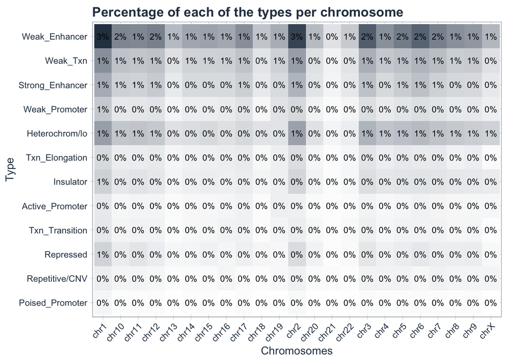

```r
heatmap <- my_data_final %>%
ggplot(aes(chrom, type)) +
  geom_tile(aes(fill = prop)) +
  geom_text(aes(label = scales::percent(prop, accuracy = 1)),
            size = 3) +
  scale_fill_gradient(low = "white",high = palette_light()[1]) +
  labs(
    title = "Percentage of each of the types per chromosome",
    x = "Chromosomes",
    y = "Type"
  )+
  theme_tq() +
  theme(
    axis.text.x = element_text(angle = 45, hjust = 1),
    legend.position = "none",
    plot.title = element_text(face = "bold"))




heatmap
```